# 父の背中—あたらしい嫁を与える者たち

Satoshi Nakagawa

# 1 Prologue

2010年、わたしはインドネシア、 フローレス島の中部のエンデの すでに馴染みとなった村 （KDR）で暮していた。 わたしは、 わたしの「妹」のOLIと その夫のYAANの家にやっかいになっていた。

ある日のこと、 村の広場で餌を食べている馬に気がついた。 見慣れる馬だ。 なんの気なしに、 そばにいたYAANに 「あれは誰の馬？」と聞いた。 「わたしの馬だ」ということである。 馬の来歴を聞いた。 答えは以下の通りだった。

二つ谷を超えた村のラサがくれたんだ。 ラサの顔は知っているけど、 とくに深いつきあいもない男だ。 彼がつぎのように言うのだ—

```
「わたしの妹が結婚することになった。
それで母親の背中だけでなく、
父親の背中も探すことになったんだ。
けっきょくお前がその父親の背中
だとわかったんだ」
```

そして、ラサが妹の婚資 （ンガヴ ）としてもらった 馬がいまYAANのところに来た、というわけなのだ。

# 2 Introduction

以上、わたしのフィールドワークで の中の一エピソードである。 「母親の背中」（ゾンゴ・イネ） (*rhonggo inE*)と 「父親の背中」（ゾンゴ・ババ） (*rhonggo baba*)とは、 この頃（最近10年から20年くらい） よく聞くようになったフレーズである。 強いて訳せば「母親の背中」とは、 「母方の嫁を与える者（カッエウンブ）」 そして 「父親の背中」とは 「父方の嫁を与える者」のことである。

## 2.1 基本知識—婚資の流れ

30年前の状況だと 何故「男の背中」が不思議な感じを 与えるのかをまず説明しておかねば ならないだろう。

その説明をするためには、 エンデにおける婚資の流れをおさえる 必要がある。

人類学において 「婚資」 (bridewealth or brideprice) という言葉は、 結婚の際に婿の側から嫁の側へ 与える**財**を指す。

エンデにおいても、 基本的にその通りなのだが、 違いはやり取りが「結婚の際」に 限られないということである。

エンデにおいては、 いちど結婚が行なわれると、 婿の側は「嫁を受け取る者」 （ウェタ・アネ）として、 嫁の側は「嫁を与える者」 （カッエ・ウンブ）として 世代を越えた関係にはいる。 ことある毎に嫁を受け取る者は 嫁を与える者に財を与えるのである。 そして、嫁を与える者の男の成員の 結婚もまた そのような機会の一つである。

そのような使い方をされる エンデのンガヴを「婚資」と訳すと 誤解を招きやすい。 これ以降は ンガヴという語を使用していく。[^1]

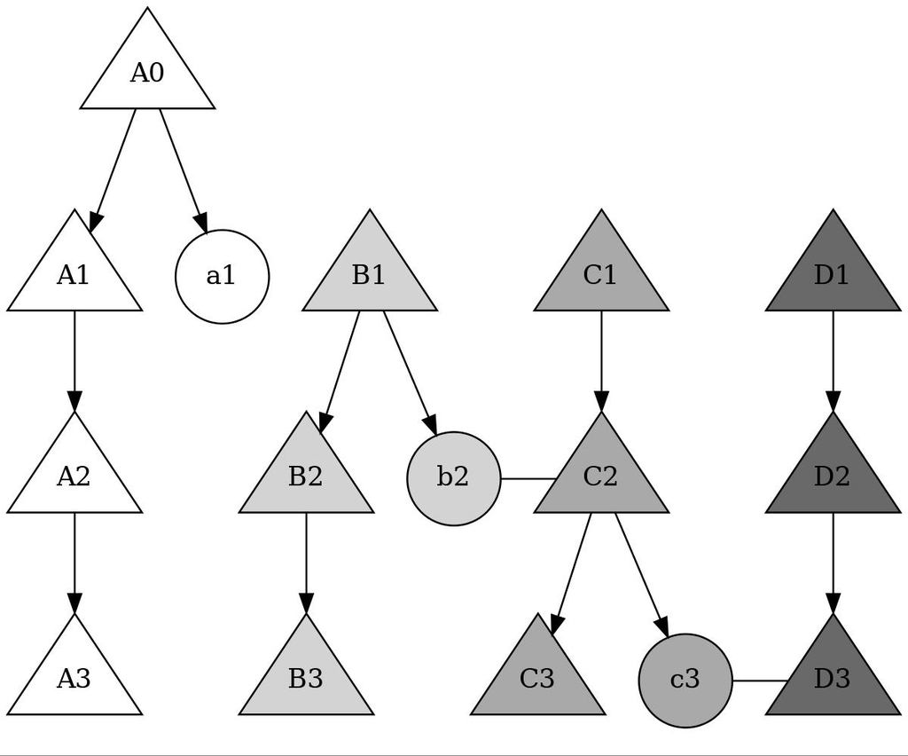

この物語の中であるンガヴは 次のように流れる— Z家からA家へ、 A家からB家へ、 そしてB家からC家へと。

```
 Z → A → B → C
```

C家の受け取ったンガヴは、 そこにとどまらない。 C家は、そのうちの大きな部分を 嫁を与える者であるD家に 贈るのである。

```
 C → D
```

すなわち、 ンガヴ支払いが行なわれると、 それを契機にエンデの社会の中を 巨大なンガヴの流れが形成されるのだ。 一方にB へと向う大きな流れができる。 B家にまとめられたンガヴは C家へと 渡される。 その後 C家からまた大きな流れとなって 社会の中を流れていくのである。

## 2.2 母方交差イトコ婚

この脈絡で エンデの結婚のイデオロギーである 母方交差イトコ婚を説明するのが もっとも理解しやすいであろう。

嫁を受け取る者と嫁を与える者の 関係は世代を越えて引き継がれると わたしは言った。 世代毎に結婚があるわけなので、 ある家において 嫁を与える者が （そしてもちろん嫁を受け取る者も） どんどん増えてくることになる。

その数を押さえるのが 母方交差イトコ婚である。[^2]

簡単に言うと、 母方交差イトコ婚とは 世代を越えて嫁を与える者が一定になるような 制度である。

## 2.3 いくつかの注意点

これまでの説明から出てくるかもしれない いくつかの誤解をあらかじめ解いておこう。

第一点は、 母方交差イトコ婚はすべての人が 従わなくてはいけない規則ではないということである。 この結婚をする人は、 むしろ、驚くほどに少ない。

第二点は、 これまでの説明では 嫁を受け取る者が嫁を与える者へと財を 贈ることに焦点をあてたが、 嫁を与える者から嫁を受け取る者へも 財は移動する。 ただし財の種類が違う。 動物で言えば、 ほとんどの動物がンガヴとして 嫁を受け取る者から嫁を与える者へと 贈られるが、 豚は例外であり、 豚は嫁を与える者から 嫁を受け取る者へと贈られるのだ。 主たる財の種類を 表にした。

贈り物のやりとり

| goods | wt → wg | wg → wt |
| --- | --- | --- |
| animals | all kinds | pigs |
| others | ivory | women |
|  | gold items | land |
|  |  | rice banana |

## 2.4 ヤーンの馬の不思議

このようなゲームの中に 「男の背中」の出る場所はない。 「女の背中」とは、 嫁を与える者の嫁を与える者で、 もっとも重要な役割を担うものである。 しかし、 「男の背中」とは 嫁を与える者の嫁を受け取る者であり、 蚊帳の外の筈なのだ。

## 2.5 サムのボウ

2010年にはもう一つ 同じような不思議な出来事があった ことを付け加えておこう。

```
+---------+
|         |
m         f === m
A               |
                m === f
                B
```

## 2.6 不思議なボウ A strange bou

## 2.7 答の背景

答を骨抜きで先取りしておく。 「男の背中」が出現した背景には カトリックによる「母方交差イトコ婚の禁止」があるのだ。 母方交差イトコ婚が禁止されることによって 出現するある社会状況を避けるために、 「男の背中」が導入されたのだ。

## 2.9 父の背中と母の背中 Mother’s back and father’s back

## 2.10 The Horse revisited

# 3

[^1]: 「ンガヴ」とは、もともと、 「財」の意味である。
[^2]: もっとも、 エンデの人もこのような機能的な 説明 （母方交差イトコ婚は 増えつづける嫁を与える者の数を 抑えるためだという説明）はしない。 またわたしもこのような機能が あるがゆえに母方交差イトコ婚が 制度としてあるのだという 事を言いたいわけではない。 結果としてそうなっているという だけである。